# PEC 2 Estadistica Avanzada

Ramon Soto

2022-05-05

## 0.1 Carga de datos

Volcado en DAtaframe y presentación de datos

```r
library(dplyr)
```

```r
library('ggplot2')
library('corrplot')
library("ggpubr")
library("faraway")
library(car)
setwd("D:/uoc/estadistica avanzada/pec3/" );

airs <-
  read.table("dat_Air_Stations.csv",
             header=TRUE, stringsAsFactors=TRUE, sep=",", na.strings="NA", dec=".",
             strip.white=TRUE)
head(airs)
```

```
##   Estacion                        Nombre  latitud  longitud      Fecha Periodo
## 1        1 Estacion Avenida Constitucion 43.52981 -5.673428 31/12/2018      10
## 2        1 Estacion Avenida Constitucion 43.52981 -5.673428 31/12/2018      11
## 3        1 Estacion Avenida Constitucion 43.52981 -5.673428 31/12/2018      12
## 4        1 Estacion Avenida Constitucion 43.52981 -5.673428 30/03/2018      11
## 5        1 Estacion Avenida Constitucion 43.52981 -5.673428 30/03/2018      12
## 6        1 Estacion Avenida Constitucion 43.52981 -5.673428 30/03/2018      13
##   SO2 NO NO2   CO  PM10 O3  dd   vv  TMP HR  PRB  RS LL  BEN  TOL MXIL PM25
## 1   4 76  38 0.38 21.20  7 271 0.10  5.1 25 1032 186  0 1.46 4.26 2.65   19
## 2   5 68  40 0.37 27.60 10 179 0.10  8.3 25 1032 275  0 1.52 4.11 4.31   24
## 3   3 23  25 0.27 21.20 28 142 0.16 10.2 25 1031 338  0 1.18 1.85 1.45   16
## 4   5  3  12 0.20  5.31 90 181 1.62 12.6 25  998 272  0 0.32 0.73 0.73    1
## 5   5  3  16 0.13  2.12 90 185 1.21 13.1 25  998 155  0 0.26 0.93 0.39    1
## 6   6  3  16 0.17  1.06 89 199 1.11 13.4 25  997 145  0 0.28 1.08 0.57    1
```

```r
str(airs)
```

```
## 'data.frame':    43799 obs. of  23 variables:
##  $ Estacion: int  1 1 1 1 1 1 1 1 1 1 ...
##  $ Nombre  : Factor w/ 5 levels "Estacion Avenida Argentina",..: 3 3 3 3 3 3 3 3 3 3 ...
##  $ latitud : num  43.5 43.5 43.5 43.5 43.5 ...
##  $ longitud: num  -5.67 -5.67 -5.67 -5.67 -5.67 ...
##  $ Fecha   : Factor w/ 365 levels "01/01/2018","01/02/2018",..: 365 365 365 349 349 349 349 349 183 216 ...
##  $ Periodo : int  10 11 12 11 12 13 14 15 13 7 ...
##  $ SO2     : int  4 5 3 5 5 6 6 6 8 3 ...
##  $ NO      : int  76 68 23 3 3 3 2 2 10 6 ...
##  $ NO2     : int  38 40 25 12 16 16 14 12 26 25 ...
##  $ CO      : num  0.38 0.37 0.27 0.2 0.13 0.17 0.14 0.14 0.32 0.39 ...
##  $ PM10    : num  21.2 27.6 21.2 5.31 2.12 1.06 2.12 3.19 9.56 7.43 ...
##  $ O3      : int  7 10 28 90 90 89 88 91 79 65 ...
##  $ dd      : int  271 179 142 181 185 199 199 173 245 180 ...
##  $ vv      : num  0.1 0.1 0.16 1.62 1.21 1.11 0.86 0.78 0.85 0.96 ...
##  $ TMP     : num  5.1 8.3 10.2 12.6 13.1 13.4 13.5 13.6 15.2 15.3 ...
##  $ HR      : int  25 25 25 25 25 25 25 25 25 25 ...
##  $ PRB     : int  1032 1032 1031 998 998 997 996 995 1001 1011 ...
##  $ RS      : int  186 275 338 272 155 145 187 144 680 54 ...
##  $ LL      : num  0 0 0 0 0 0 0 0 0 0 ...
##  $ BEN     : num  1.46 1.52 1.18 0.32 0.26 0.28 0.27 0.28 0.31 0.4 ...
##  $ TOL     : num  4.26 4.11 1.85 0.73 0.93 1.08 0.48 0.62 2.53 0.74 ...
##  $ MXIL    : num  2.65 4.31 1.45 0.73 0.39 0.57 0.55 0.66 1.91 0.49 ...
##  $ PM25    : int  19 24 16 1 1 1 1 1 9 5 ...
```

```r
summary(airs)
```

```
##     Estacion                                   Nombre        latitud
##  Min.   : 1   Estacion Avenida Argentina          :8760   Min.   :43.52
##  1st Qu.: 2   Estacion Avenida Castilla           :8760   1st Qu.:43.53
##  Median : 3   Estacion Avenida Constitucion       :8760   Median :43.54
##  Mean   : 4   Estacion Avenida Hermanos Felgueroso:8759   Mean   :43.53
##  3rd Qu.: 4   Estacion de Montevil                :8760   3rd Qu.:43.54
##  Max.   :10                                               Max.   :43.54
##
##     longitud             Fecha          Periodo          SO2
##  Min.   :-5.699   01/01/2018:  120   Min.   : 1.0   Min.   : 1.000
##  1st Qu.:-5.673   01/02/2018:  120   1st Qu.: 7.0   1st Qu.: 3.000
##  Median :-5.672   01/03/2018:  120   Median :13.0   Median : 5.000
##  Mean   :-5.670   01/04/2018:  120   Mean   :12.5   Mean   : 5.701
##  3rd Qu.:-5.658   01/05/2018:  120   3rd Qu.:18.5   3rd Qu.: 7.000
##  Max.   :-5.646   01/06/2018:  120   Max.   :24.0   Max.   :90.000
##                   (Other)   :43079                  NA's   :598
##        NO              NO2               CO             PM10
##  Min.   :  1.00   Min.   :  1.00   Min.   :0.100   Min.   :  0.00
##  1st Qu.:  2.00   1st Qu.: 12.00   1st Qu.:0.190   1st Qu.: 14.90
##  Median :  5.00   Median : 20.00   Median :0.300   Median : 22.30
##  Mean   : 13.04   Mean   : 24.49   Mean   :0.396   Mean   : 25.24
##  3rd Qu.: 11.00   3rd Qu.: 33.00   3rd Qu.:0.470   3rd Qu.: 30.80
##  Max.   :394.00   Max.   :130.00   Max.   :9.510   Max.   :395.00
##  NA's   :332      NA's   :349      NA's   :9075    NA's   :546
##        O3               dd              vv              TMP
##  Min.   :  1.00   Min.   :  0.0   Min.   : 0.000   Min.   :-1.60
##  1st Qu.: 24.00   1st Qu.:135.0   1st Qu.: 0.170   1st Qu.:10.80
##  Median : 49.00   Median :197.0   Median : 0.640   Median :14.90
##  Mean   : 47.24   Mean   :202.1   Mean   : 0.949   Mean   :14.92
##  3rd Qu.: 68.00   3rd Qu.:295.0   3rd Qu.: 1.350   3rd Qu.:19.00
##  Max.   :134.00   Max.   :360.0   Max.   :11.800   Max.   :30.90
##  NA's   :652      NA's   :26617   NA's   :26617    NA's   :26389
##        HR             PRB              RS              LL
##  Min.   : 25.0   Min.   : 969    Min.   :  2.0   Min.   : 0.00
##  1st Qu.: 68.0   1st Qu.:1010    1st Qu.:  4.0   1st Qu.: 0.00
##  Median : 80.0   Median :1015    Median : 54.0   Median : 0.00
##  Mean   : 78.2   Mean   :1014    Mean   :110.6   Mean   : 0.12
##  3rd Qu.: 90.0   3rd Qu.:1020    3rd Qu.:110.0   3rd Qu.: 0.00
##  Max.   :100.0   Max.   :1038    Max.   :841.0   Max.   :19.00
##  NA's   :26389   NA's   :26389   NA's   :26389   NA's   :26389
##       BEN             TOL              MXIL             PM25
##  Min.   :0.12    Min.   :  0.03   Min.   :  0.03   Min.   : 1.00
##  1st Qu.:0.24    1st Qu.:  0.64   1st Qu.:  0.27   1st Qu.: 5.00
##  Median :0.39    Median :  1.37   Median :  0.82   Median : 9.00
##  Mean   :0.58    Mean   :  2.83   Mean   :  2.28   Mean   :10.29
##  3rd Qu.:0.66    3rd Qu.:  3.02   3rd Qu.:  2.29   3rd Qu.:14.00
##  Max.   :9.53    Max.   :182.00   Max.   :134.00   Max.   :96.00
##  NA's   :35224   NA's   :35224    NA's   :35559    NA's   :26502
```

# 1 Regresión Lineal

## 1.1 Estudio comparativo de las estaciones

```r
airs$Fecha<-as.Date(airs$Fecha, "%m/%d/%y")

OMS_media_PM10<-45
OMS_media_O3<-60
OMS_media_SO2<-40
OMS_media_NO2<-25
OMS_max_diaria_O3<-100
OMS_max_diaria_NO2<-120

max_med<-airs %>%
  group_by(Fecha,Nombre) %>%
  summarize(mediaPM10 = mean(PM10, na.rm=TRUE), maxPM10=max(PM10),
            mediaNO2 = mean(NO2, na.rm=TRUE), maxNO2=max(NO2),
            mediaO3 = mean(O3, na.rm=TRUE), maxO3=max(O3),
            mediaSO2 = mean(SO2, na.rm=TRUE), maxNSO2=max(SO2))
supera_OMS_PM10<-select((max_med%>%filter(mediaPM10>OMS_media_PM10)),Nombre)%>%
  group_by(Nombre) %>%summarize(n = n())%>%arrange(n)
supera_OMS_O3<-select((max_med%>%filter(mediaO3>OMS_media_O3)),Nombre)%>%
  group_by(Nombre) %>%summarize(n = n())%>%arrange(n)
supera_OMS_SO2<-select((max_med%>%filter(mediaSO2>OMS_media_SO2)),Nombre)%>%
  group_by(Nombre) %>%summarize(n = n())%>%arrange(n)
supera_OMS_NO2<-select((max_med%>%filter(mediaNO2>OMS_media_NO2)),Nombre)%>%
  group_by(Nombre) %>%summarize(n = n())%>%arrange(n)
supera_OMS_maxO3<-select((max_med%>%filter(maxO3>OMS_max_diaria_O3)),Nombre)%>%
  group_by(Nombre) %>%summarize(n = n())%>%arrange(n)
supera_OMS__maxNO2<-select((max_med%>%filter(maxNO2>OMS_max_diaria_NO2)),Nombre)%>%
  group_by(Nombre) %>%summarize(n = n())%>%arrange(n)
supera_OMS_PM10
```

```
## # A tibble: 4 x 2
##   Nombre                                   n
##   <fct>                                <int>
## 1 Estacion de Montevil                     4
## 2 Estacion Avenida Hermanos Felgueroso     5
## 3 Estacion Avenida Castilla                8
## 4 Estacion Avenida Argentina               9
```

```r
supera_OMS_O3
```

```
## # A tibble: 5 x 2
##   Nombre                                   n
##   <fct>                                <int>
## 1 Estacion Avenida Constitucion           27
## 2 Estacion Avenida Argentina              38
## 3 Estacion Avenida Hermanos Felgueroso    38
## 4 Estacion de Montevil                    52
## 5 Estacion Avenida Castilla               56
```

```r
supera_OMS_SO2
```

```
## # A tibble: 0 x 2
## # ... with 2 variables: Nombre <fct>, n <int>
```

```r
supera_OMS_NO2
```

```
## # A tibble: 5 x 2
##   Nombre                                   n
##   <fct>                                <int>
## 1 Estacion Avenida Castilla               37
## 2 Estacion de Montevil                    37
## 3 Estacion Avenida Argentina              69
## 4 Estacion Avenida Constitucion           84
## 5 Estacion Avenida Hermanos Felgueroso    93
```

```r
supera_OMS_maxO3
```

```
## # A tibble: 5 x 2
##   Nombre                                   n
##   <fct>                                <int>
## 1 Estacion Avenida Constitucion            6
## 2 Estacion Avenida Hermanos Felgueroso     7
## 3 Estacion Avenida Argentina              12
## 4 Estacion de Montevil                    14
## 5 Estacion Avenida Castilla               19
```

```r
supera_OMS__maxNO2
```

```
## # A tibble: 2 x 2
##   Nombre                            n
##   <fct>                         <int>
## 1 Estacion Avenida Argentina        1
## 2 Estacion Avenida Constitucion     1
```

## 1.2 b

```r
# aux = airs %>% distinct(Estacion)
# distinct_Estacion = aux$Estacion

# v<-ggplot(data = max_med[max_med$Estacion==1,], aes(x =Fecha , y = maxPM10)) +geom_line(color = "#00AFBB", size = 2)+ geom_smooth(color = "firebrick") + theme_bw() +ggtitle("Estacion 1")
#
# b<-ggplot(data = max_med[max_med$Estacion==2,], aes(x =Fecha , y = maxPM10)) +geom_line(color = "#00AFBB", size = 2)+ geom_smooth(color = "firebrick") + theme_bw() +ggtitle("Estacion 2")
#
# n<-ggplot(data = max_med[max_med$Estacion==3,], aes(x =Fecha , y = maxPM10)) +geom_line(color = "#00AFBB", size = 2)+ geom_smooth(color = "firebrick") + theme_bw() +ggtitle("Estacion 3")
#
# m<-ggplot(data = max_med[max_med$Estacion==4,], aes(x =Fecha , y = maxPM10)) +geom_line(color = "#00AFBB", size = 2)+ geom_smooth(color = "firebrick") + theme_bw() +ggtitle("Estacion 4")
#
# k<-ggplot(data = max_med[max_med$Estacion==10,], aes(x =Fecha , y = maxPM10)) +geom_line(color = "#00AFBB", size = 2)+ geom_smooth(color = "firebrick") + theme_bw() +ggtitle("Estacion 10")
#
# ggarrange(v,b,n,m,k,
#
#           ncol = 2, nrow = 3)
#
#
# v<-ggplot(data = max_med[max_med$Estacion==1,], aes(x =Fecha , y = maxNO2)) +geom_line(color = "#00AFBB", size = 2)+ geom_smooth(color = "firebrick") + theme_bw() +ggtitle("Estacion 1")
#
# b<-ggplot(data = max_med[max_med$Estacion==2,], aes(x =Fecha , y = maxNO2)) +geom_line(color = "#00AFBB", size = 2)+ geom_smooth(color = "firebrick") + theme_bw() +ggtitle("Estacion 2")
#
# n<-ggplot(data = max_med[max_med$Estacion==3,], aes(x =Fecha , y = maxNO2)) +geom_line(color = "#00AFBB", size = 2)+ geom_smooth(color = "firebrick") + theme_bw() +ggtitle("Estacion 3")
#
# m<-ggplot(data = max_med[max_med$Estacion==4,], aes(x =Fecha , y = maxNO2)) +geom_line(color = "#00AFBB", size = 2)+ geom_smooth(color = "firebrick") + theme_bw() +ggtitle("Estacion 4")
#
# k<-ggplot(data = max_med[max_med$Estacion==10,], aes(x =Fecha , y = maxNO2)) +geom_line(color = "#00AFBB", size = 2)+ geom_smooth(color = "firebrick") + theme_bw() +ggtitle("Estacion 10")
#
# ggarrange(v,b,n,m,k,
#
#           ncol = 2, nrow = 3)
#
#
# v<-ggplot(data = max_med[max_med$Estacion==1,], aes(x =Fecha , y = maxO3)) +geom_line(color = "#00AFBB", size = 2)+ geom_smooth(color = "firebrick") + theme_bw() +ggtitle("Estacion 1")
#
# b<-ggplot(data = max_med[max_med$Estacion==2,], aes(x =Fecha , y = maxO3)) +geom_line(color = "#00AFBB", size = 2)+ geom_smooth(color = "firebrick") + theme_bw() +ggtitle("Estacion 2")
#
# n<-ggplot(data = max_med[max_med$Estacion==3,], aes(x =Fecha , y = maxO3)) +geom_line(color = "#00AFBB", size = 2)+ geom_smooth(color = "firebrick") + theme_bw() +ggtitle("Estacion 3")
#
# m<-ggplot(data = max_med[max_med$Estacion==4,], aes(x =Fecha , y = maxO3)) +geom_line(color = "#00AFBB", size = 2)+ geom_smooth(color = "firebrick") + theme_bw() +ggtitle("Estacion 4")
#
# k<-ggplot(data = max_med[max_med$Estacion==10,], aes(x =Fecha , y = maxO3)) +geom_line(color = "#00AFBB", size = 2)+ geom_smooth(color = "firebrick") + theme_bw() +ggtitle("Estacion 10")
#
# ggarrange(v,b,n,m,k,
#
#           ncol = 2, nrow = 3)
#
#
# v<-ggplot(data = max_med[max_med$Estacion==1,], aes(x =Fecha , y = maxNSO2)) +geom_line(color = "#00AFBB", size = 2)+ geom_smooth(color = "firebrick") + theme_bw() +ggtitle("Estacion 1")
#
# b<-ggplot(data = max_med[max_med$Estacion==2,], aes(x =Fecha , y = maxNSO2)) +geom_line(color = "#00AFBB", size = 2)+ geom_smooth(color = "firebrick") + theme_bw() +ggtitle("Estacion 2")
#
# n<-ggplot(data = max_med[max_med$Estacion==3,], aes(x =Fecha , y = maxNSO2)) +geom_line(color = "#00AFBB", size = 2)+ geom_smooth(color = "firebrick") + theme_bw() +ggtitle("Estacion 3")
#
# m<-ggplot(data = max_med[max_med$Estacion==4,], aes(x =Fecha , y = maxNSO2)) +geom_line(color = "#00AFBB", size = 2)+ geom_smooth(color = "firebrick") + theme_bw() +ggtitle("Estacion 4")
#
# k<-ggplot(data = max_med[max_med$Estacion==10,], aes(x =Fecha , y = maxNSO2)) +geom_line(color = "#00AFBB", size = 2)+ geom_smooth(color = "firebrick") + theme_bw() +ggtitle("Estacion 10")
#
# ggarrange(v,b,n,m,k,
#
#           ncol = 2, nrow = 3)
```

1.1 c

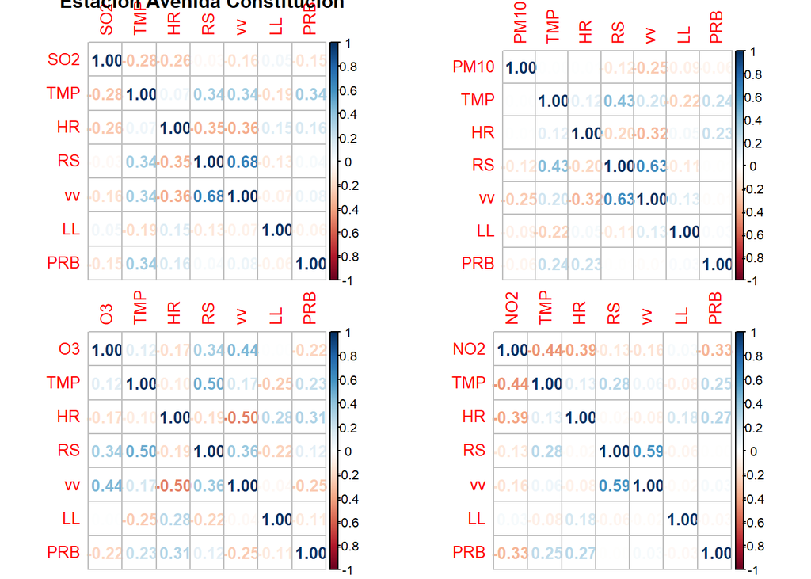

```r
dibuja_correlaciones <-function(i) {
estacion_SO2<-airs %>%filter(Nombre==i) %>%group_by(Fecha)%>%filter(SO2==max(SO2))%>%select(Fecha,SO2,TMP,HR,RS,vv,LL,PRB)
elim.pos <- which(names(estacion_SO2)=="Fecha")
estacion_SO2<-estacion_SO2[,-elim.pos]

mat_Cor1<-cor(na.omit(estacion_SO2))

#corrplot(mat_Cor, method = 'number')


estacion_PM10<-airs %>%filter(Nombre==i) %>%group_by(Fecha)%>%filter(PM10==max(PM10))%>%select(Fecha,PM10,TMP,HR,RS,vv,LL,PRB)
elim.pos <- which(names(estacion_PM10)=="Fecha")
estacion_PM10<-estacion_PM10[,-elim.pos]

mat_Cor2<-cor(na.omit(estacion_PM10))

#corrplot(mat_Cor, method = 'number')


estacion_O3<-airs %>%filter(Nombre==i) %>%group_by(Fecha)%>%filter(O3==max(O3))%>%select(Fecha,O3,TMP,HR,RS,vv,LL,PRB)
elim.pos <- which(names(estacion_O3)=="Fecha")
estacion_O3<-estacion_O3[,-elim.pos]

mat_Cor3<-cor(na.omit(estacion_O3))

#corrplot(mat_Cor, method = 'number')

estacion_NO2<-airs %>%filter(Nombre==i) %>%group_by(Fecha)%>%filter(NO2==max(NO2))%>%select(Fecha,NO2,TMP,HR,RS,vv,LL,PRB)
elim.pos <- which(names(estacion_NO2)=="Fecha")
estacion_NO2<-estacion_NO2[,-elim.pos]

mat_Cor4<-cor(na.omit(estacion_NO2))

#corrplot(mat_Cor, method = 'number')

par( mfrow=c(2,2))
corrplot(mat_Cor1, method = 'number', title=as.character(i))
corrplot(mat_Cor2, method = 'number')
corrplot(mat_Cor3, method = 'number')
corrplot(mat_Cor4, method = 'number')
par( mfrow=c(1,1))


}
dibuja_correlaciones("Estacion Avenida Constitucion")
```

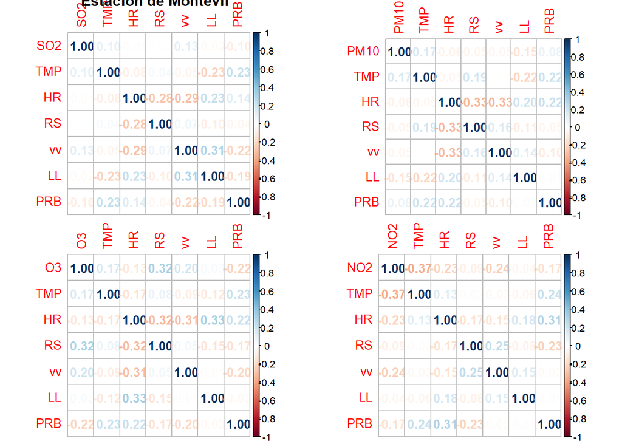

```r
dibuja_correlaciones("Estacion de Montevil")
```

## 1.3 1.2 Modelos de regresión lineal

Hacemos la regresión lineal tomando O3 como variable dependiente y NO2 como variable independiente.

Fijándonos el valor de R^2 sacamos la conclusión de que la varianza de la regresión explica sólo alrededor del 42% de la varianza de todos los datos. Es muy lejano a 1 por tantola no es un buen ajuste.

```r
model <- lm(O3 ~ NO2 , data = airs)
summary(model)
```

```
##
## Call:
## lm(formula = O3 ~ NO2, data = airs)
##
## Residuals:
##     Min      1Q  Median      3Q     Max
## -63.353 -13.910   0.828  13.868  85.682
##
## Coefficients:
##              Estimate Std. Error t value Pr(>|t|)
## (Intercept) 72.649230   0.174380   416.6   <2e-16 ***
## NO2         -1.036976   0.005861  -176.9   <2e-16 ***
## ---
## Signif. codes:  0 '***' 0.001 '**' 0.01 '*' 0.05 '.' 0.1 ' ' 1
##
## Residual standard error: 20.53 on 43118 degrees of freedom
##   (679 observations deleted due to missingness)
## Multiple R-squared:  0.4207, Adjusted R-squared:  0.4206
## F-statistic: 3.131e+04 on 1 and 43118 DF,  p-value: < 2.2e-16
```

A continuación vamos a añadir la variable de los nombres de las estaciones. La funcion lm la trasnformara en 4 variables dummies de acuerdo a este patrón de abajo.

Cuando las cuatro variables binarias valgan cero la regresión nos hará la estimacion del valor de O3 para la “Estación de Avenida Argentina”, quedando determinado por el valor “Intercept”

```r
contrasts(airs$Nombre)
```

```
##                                      Estacion Avenida Castilla
## Estacion Avenida Argentina                                   0
## Estacion Avenida Castilla                                    1
## Estacion Avenida Constitucion                                0
## Estacion Avenida Hermanos Felgueroso                         0
## Estacion de Montevil                                         0
##                                      Estacion Avenida Constitucion
## Estacion Avenida Argentina                                       0
## Estacion Avenida Castilla                                        0
## Estacion Avenida Constitucion                                    1
## Estacion Avenida Hermanos Felgueroso                             0
## Estacion de Montevil                                             0
##                                      Estacion Avenida Hermanos Felgueroso
## Estacion Avenida Argentina                                              0
## Estacion Avenida Castilla                                               0
## Estacion Avenida Constitucion                                           0
## Estacion Avenida Hermanos Felgueroso                                    1
## Estacion de Montevil                                                    0
##                                      Estacion de Montevil
## Estacion Avenida Argentina                              0
## Estacion Avenida Castilla                               0
## Estacion Avenida Constitucion                           0
## Estacion Avenida Hermanos Felgueroso                    0
## Estacion de Montevil                                    1
```

```r
model <- lm(O3 ~ NO2+Nombre , data = airs)
summary(model)
```

```
##
## Call:
## lm(formula = O3 ~ NO2 + Nombre, data = airs)
##
## Residuals:
##     Min      1Q  Median      3Q     Max
## -60.684 -13.871   0.679  13.893  85.154
##
## Coefficients:
##                                             Estimate Std. Error  t value
## (Intercept)                                75.305599   0.266607  282.459
## NO2                                        -1.065195   0.006029 -176.693
## NombreEstacion Avenida Castilla            -5.100212   0.312240  -16.334
## NombreEstacion Avenida Constitucion        -1.112099   0.312823   -3.555
## NombreEstacion Avenida Hermanos Felgueroso  0.231370   0.311964    0.742
## NombreEstacion de Montevil                 -3.788765   0.311481  -12.164
##                                            Pr(>|t|)
## (Intercept)                                 < 2e-16 ***
## NO2                                         < 2e-16 ***
## NombreEstacion Avenida Castilla             < 2e-16 ***
## NombreEstacion Avenida Constitucion        0.000378 ***
## NombreEstacion Avenida Hermanos Felgueroso 0.458300
## NombreEstacion de Montevil                  < 2e-16 ***
## ---
## Signif. codes:  0 '***' 0.001 '**' 0.01 '*' 0.05 '.' 0.1 ' ' 1
##
## Residual standard error: 20.42 on 43114 degrees of freedom
##   (679 observations deleted due to missingness)
## Multiple R-squared:  0.4266, Adjusted R-squared:  0.4265
## F-statistic:  6415 on 5 and 43114 DF,  p-value: < 2.2e-16
```

## 1.4 1.3 Regresion lineal múltiple

### 1.4.1 A)

Construimos el modelo para cada una de las estaciones de incluyendo las variables indicadas.

Para la estación de Montevil todos los coeficientes de las variables independientes con un nivel de significancia próximo a cero.

Para No2 y HR la correlación es negativa. Si volvemos a la matriz de correlaciones para O3 y HR en con los datos totales de esta estación coincide el signo de la correlación.

El coeficiente de determinación sube casi en 0.2 puntos con respecto a los dos modelos anteriores, sin embargo sigue estando au´n demasiado alejado de 1.

```r
data_Montevil<- airs %>% filter(Nombre=="Estacion de Montevil") %>% select(O3,NO2,vv,RS,HR,LL,TMP)
modelo_Montevil <- lm(O3 ~ NO2 + vv + RS +HR +LL, data = data_Montevil)
summary(modelo_Montevil)
```

```
##
## Call:
## lm(formula = O3 ~ NO2 + vv + RS + HR + LL, data = data_Montevil)
##
## Residuals:
##    Min     1Q Median     3Q    Max
## -51.86 -12.66  -1.02  10.93  70.68
##
## Coefficients:
##              Estimate Std. Error t value Pr(>|t|)
## (Intercept) 87.083516   1.446493  60.203   <2e-16 ***
## NO2         -1.082711   0.013968 -77.512   <2e-16 ***
## vv           4.743372   0.198630  23.880   <2e-16 ***
## RS           0.031481   0.001496  21.042   <2e-16 ***
## HR          -0.293340   0.014337 -20.461   <2e-16 ***
## LL           2.586381   0.305459   8.467   <2e-16 ***
## ---
## Signif. codes:  0 '***' 0.001 '**' 0.01 '*' 0.05 '.' 0.1 ' ' 1
##
## Residual standard error: 17.47 on 8661 degrees of freedom
##   (93 observations deleted due to missingness)
## Multiple R-squared:  0.6109, Adjusted R-squared:  0.6107
## F-statistic:  2720 on 5 and 8661 DF,  p-value: < 2.2e-16
```

```r
data_Constitucion<- airs %>% filter(Nombre=="Estacion Avenida Constitucion") %>% select(O3,NO2,vv,RS,HR,LL,TMP)
modelo_Constitucion <- lm(O3 ~ NO2 + vv + RS +HR +LL, data = data_Constitucion)
summary(modelo_Constitucion)
```

```
##
## Call:
## lm(formula = O3 ~ NO2 + vv + RS + HR + LL, data = data_Constitucion)
##
## Residuals:
##     Min      1Q  Median      3Q     Max
## -79.604 -12.997  -0.311  11.341  64.797
##
## Coefficients:
##              Estimate Std. Error t value Pr(>|t|)
## (Intercept) 83.105742   1.503345  55.281  < 2e-16 ***
## NO2         -0.770074   0.011100 -69.374  < 2e-16 ***
## vv          15.193432   0.477656  31.808  < 2e-16 ***
## RS           0.007788   0.001378   5.651 1.65e-08 ***
## HR          -0.352352   0.016727 -21.065  < 2e-16 ***
## LL           2.846492   0.352262   8.081 7.35e-16 ***
## ---
## Signif. codes:  0 '***' 0.001 '**' 0.01 '*' 0.05 '.' 0.1 ' ' 1
##
## Residual standard error: 17.83 on 8276 degrees of freedom
##   (478 observations deleted due to missingness)
## Multiple R-squared:  0.5904, Adjusted R-squared:  0.5902
## F-statistic:  2386 on 5 and 8276 DF,  p-value: < 2.2e-16
```

### 1.4.2 B)

Al introducir como variable independiente TMP, para Montevil el coeficiente de determinación apenas sube del 0.61 al 0.612

Para la otra estación ni lo mejora. Es más TMP tienen un nivel de significancia cercano a 1, luego de ahí se deduce que es mejor quitarla del modelo.

```r
modelo_Montevil <- lm(O3 ~ NO2 + vv + RS +HR +LL+TMP, data = data_Montevil)
summary(modelo_Montevil)
```

```
##
## Call:
## lm(formula = O3 ~ NO2 + vv + RS + HR + LL + TMP, data = data_Montevil)
##
## Residuals:
##     Min      1Q  Median      3Q     Max
## -54.863 -12.705  -1.027  11.040  69.931
##
## Coefficients:
##              Estimate Std. Error t value Pr(>|t|)
## (Intercept) 81.498647   1.691628  48.178  < 2e-16 ***
## NO2         -1.057347   0.014502 -72.912  < 2e-16 ***
## vv           4.900684   0.199737  24.536  < 2e-16 ***
## RS           0.030898   0.001496  20.660  < 2e-16 ***
## HR          -0.279089   0.014481 -19.273  < 2e-16 ***
## LL           2.747752   0.305837   8.984  < 2e-16 ***
## TMP          0.237141   0.037469   6.329 2.59e-10 ***
## ---
## Signif. codes:  0 '***' 0.001 '**' 0.01 '*' 0.05 '.' 0.1 ' ' 1
##
## Residual standard error: 17.43 on 8660 degrees of freedom
##   (93 observations deleted due to missingness)
## Multiple R-squared:  0.6127, Adjusted R-squared:  0.6124
## F-statistic:  2283 on 6 and 8660 DF,  p-value: < 2.2e-16
```

```r
modelo_Constitucion <- lm(O3 ~ NO2 + vv + RS +HR +LL+TMP, data = data_Constitucion)
summary(modelo_Constitucion)
```

```
##
## Call:
## lm(formula = O3 ~ NO2 + vv + RS + HR + LL + TMP, data = data_Constitucion)
##
## Residuals:
##     Min      1Q  Median      3Q     Max
## -79.610 -13.003  -0.309  11.341  64.784
##
## Coefficients:
##              Estimate Std. Error t value Pr(>|t|)
## (Intercept) 83.091223   1.595550  52.077  < 2e-16 ***
## NO2         -0.769998   0.011445 -67.276  < 2e-16 ***
## vv          15.194078   0.478275  31.768  < 2e-16 ***
## RS           0.007775   0.001468   5.296 1.21e-07 ***
## HR          -0.352388   0.016780 -21.000  < 2e-16 ***
## LL           2.847457   0.354070   8.042 1.01e-15 ***
## TMP          0.001180   0.043431   0.027    0.978
## ---
## Signif. codes:  0 '***' 0.001 '**' 0.01 '*' 0.05 '.' 0.1 ' ' 1
##
## Residual standard error: 17.83 on 8275 degrees of freedom
##   (478 observations deleted due to missingness)
## Multiple R-squared:  0.5904, Adjusted R-squared:  0.5901
## F-statistic:  1988 on 6 and 8275 DF,  p-value: < 2.2e-16
```

https://quantifyinghealth.com/vif-threshold/

```r
vif(modelo_Montevil)
```

```
##      NO2       vv       RS       HR       LL      TMP
## 1.284549 1.504052 1.258373 1.499060 1.062499 1.136578
```

```r
vif(modelo_Constitucion)
```

```
##      NO2       vv       RS       HR       LL      TMP
## 1.332209 1.760187 1.606862 1.378497 1.058712 1.297911
```

## 1.5 Diagnosis del modelo

Si el modelo lineal obtenido se ajusta bien a los datos muestrales, entonces la nube de puntos ( , ei) no debe mostrar ningún tipo de estructura.

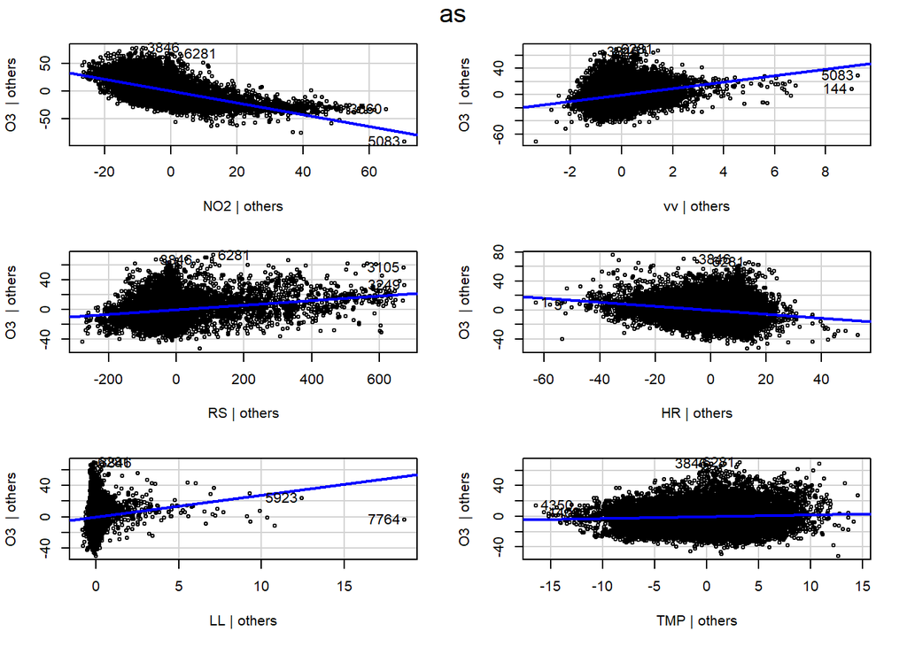

```r
avPlots(modelo_Montevil, main="as")
```

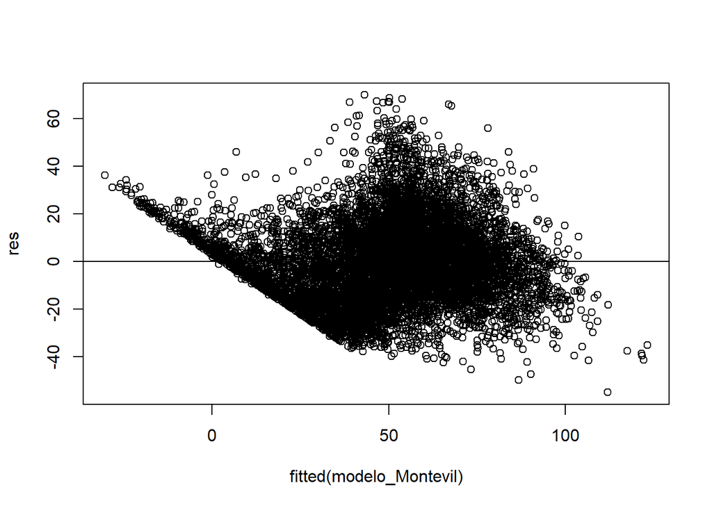

```r
res <- resid(modelo_Montevil)

plot(fitted(modelo_Montevil), res)
abline(0,0)
```

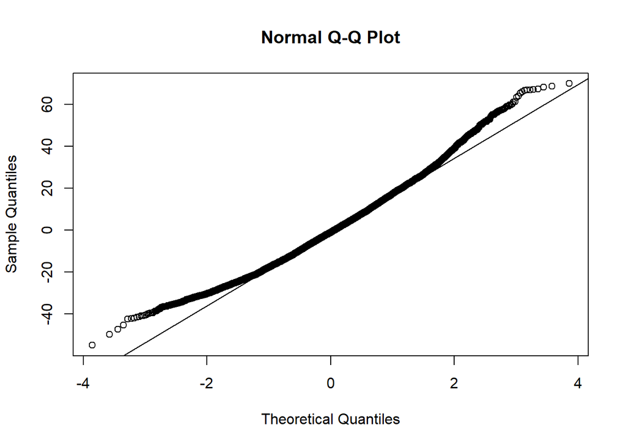

```r
qqnorm(res)


qqline(res)
```

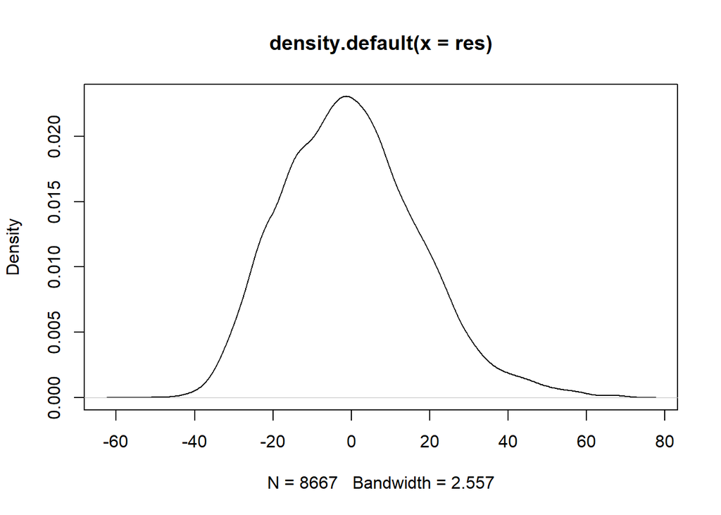

```r
plot(density(res))
```

## 1.6 Predicción del modelo

USamos la función predict para estimar con el modleo los valores de los perdictores que se especifican en el enunciado.

```r
newdf <- data.frame(NO2=c(40),vv=c(2),RS=c(100),HR=c(80),LL=(0.10),TMP=c(25))
predict(modelo_Montevil,newdf)
```

```
##        1
## 35.97204
```

# 2 Regresión Logistica

```r
airs$icPM10<-NULL

airs$icPM10[(airs["PM10"]>0)&(airs["PM10"]<=45)]="aceptable"
airs$icPM10[(airs["PM10"]>45)&(airs["PM10"]<=180)]="mejorable"


airs$icO3<-NULL

airs$icO3[(airs["O3"]>0)&(airs["O3"]<=60)]="aceptable"
airs$icO3[(airs["O3"]>60)&(airs["O3"]<=170)]="mejorable"



airs$RSre<-NULL

airs$RSre[(airs["RS"]>0)&(airs["RS"]<=100)]="normal baja"
airs$RSre[(airs["RS"]>100)&(airs["RS"]<=700)]="normal alta"
```

## 2.1 Análisis crudo